# Mini-Project #02: Identifying Environmentally Responsible US Public Transit Systems

## Task 6: Normalize Emissions to Transit Usage

Now I’ll normalize the emissions by passenger trips and miles:

```r
normalized_emissions <- emissions_data %>%
  inner_join(NTD_SERVICE %>% select(`NTD ID`, UPT, MILES), by = "NTD ID") %>%
  mutate(
    co2_per_upt = total_co2_emissions / UPT,
    co2_per_mile = total_co2_emissions / MILES
  ) %>%
  filter(!is.infinite(co2_per_upt), !is.na(co2_per_upt),
         !is.infinite(co2_per_mile), !is.na(co2_per_mile))


agency_emissions <- normalized_emissions %>%
  group_by(`Agency Name`, State) %>%
  summarize(
    total_co2_emissions = sum(total_co2_emissions),
    total_upt = sum(UPT),
    total_miles = sum(MILES),
    co2_per_upt = total_co2_emissions / total_upt,
    co2_per_mile = total_co2_emissions / total_miles,
    .groups = "drop"
  )


agency_emissions <- agency_emissions %>%
  mutate(size_category = case_when(
    total_miles > 1000000000 ~ "Large",
    total_miles > 100000000 ~ "Medium",
    TRUE ~ "Small"
  ))


efficient_agencies <- agency_emissions %>%
  filter(total_miles > 10000000) %>% # Filter out very small agencies
  arrange(co2_per_mile) %>%
  head(10)

efficient_agencies %>%
  select(`Agency Name`, State, co2_per_mile, size_category, total_miles) %>%
  mutate(
    co2_per_mile = round(co2_per_mile, 2),
    total_miles = number(total_miles, big.mark = ",")
  ) %>%
  kable(caption = "Top 10 Most Efficient Transit Agencies (CO2 lbs per Passenger Mile)") %>%
  kable_styling(bootstrap_options = c("striped", "hover"), full_width = FALSE) %>%
  row_spec(1, bold = TRUE, background = "#f9e6ff")
```

Top 10 Most Efficient Transit Agencies (CO2 lbs per Passenger Mile)

| Agency Name | State | co2_per_mile | size_category | total_miles |
| --- | --- | --- | --- | --- |
| Birmingham-Jefferson County Transit Authority | AL | 0.02 | Small | 27,996,114 |
| Greater Richmond Transit Company | VA | 0.02 | Medium | 193,642,016 |
| County of Nassau | NY | 0.02 | Medium | 225,514,606 |
| MTA New York City Transit | NY | 0.03 | Large | 47,956,268,290 |
| Centre Area Transportation Authority | PA | 0.04 | Small | 35,966,529 |
| Tri-County Metropolitan Transportation District of Oregon | OR | 0.04 | Medium | 694,291,140 |
| St. Cloud Metropolitan Transit Commission | MN | 0.05 | Small | 10,362,303 |
| County of Miami-Dade | FL | 0.05 | Large | 2,484,773,868 |
| Rock Island County Metropolitan Mass Transit District | IL | 0.05 | Small | 28,493,586 |
| Arlington County, Virginia | VA | 0.05 | Small | 10,547,892 |

Let’s visualize the efficiency of agencies by size category:

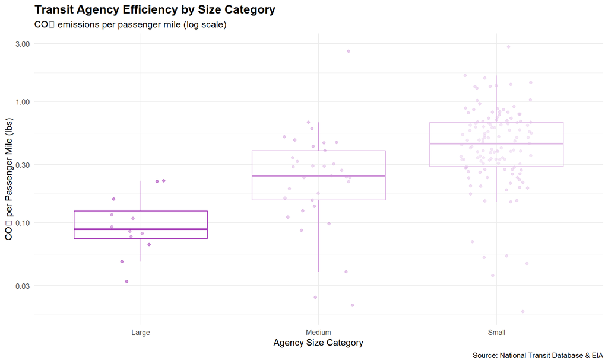

```r
medians <- agency_emissions %>%
  group_by(size_category) %>%
  summarize(median_co2_per_mile = median(co2_per_mile, na.rm = TRUE))


ggplot(agency_emissions %>% filter(total_miles > 10000000),
       aes(x = size_category, y = co2_per_mile, color = size_category)) +
  geom_jitter(alpha = 0.5, width = 0.2) +
  geom_boxplot(alpha = 0.3, outlier.shape = NA) +
  scale_color_manual(values = c("Small" = "#E1BEE7", "Medium" = "#CE93D8", "Large" = "#9C27B0")) +
  scale_y_log10() +
  labs(
    title = "Transit Agency Efficiency by Size Category",
    subtitle = "CO₂ emissions per passenger mile (log scale)",
    x = "Agency Size Category",
    y = "CO₂ per Passenger Mile (lbs)",
    caption = "Source: National Transit Database & EIA"
  ) +
  theme_minimal() +
  theme(
    plot.title = element_text(face = "bold", size = 14),
    legend.position = "none"
  )
```

The boxplot visualization reveals the distribution of emissions efficiency across different agency size categories. Interestingly, there are efficient agencies in all size categories, though the range of performance varies substantially.

## Task 7: Determine Award Winners

Now I’ll determine the winners for each of the four GTA IV Green Transit Awards based on our analysis.

### Greenest Transit Agency Award

```r
greenest_agency <- agency_emissions %>%
  filter(total_miles > 50000000) %>%

  arrange(co2_per_mile) %>%
  slice(1)


national_avg <- agency_emissions %>%
  summarize(
    avg_co2_per_mile = sum(total_co2_emissions) / sum(total_miles)
  ) %>%
  pull(avg_co2_per_mile)

# Display the winner
greenest_agency %>%
  mutate(
    national_avg = national_avg,
    improvement = (1 - co2_per_mile / national_avg) * 100
  ) %>%
  select(`Agency Name`, State, co2_per_mile, national_avg, improvement) %>%
  mutate(
    co2_per_mile = round(co2_per_mile, 2),
    national_avg = round(national_avg, 2),
    improvement = round(improvement, 1)
  ) %>%
  kable(caption = "Greenest Transit Agency Award Winner") %>%
  kable_styling(bootstrap_options = c("striped", "hover"), full_width = FALSE) %>%
  row_spec(1, bold = TRUE, background = "#f9e6ff")
```

Greenest Transit Agency Award Winner

| Agency Name | State | co2_per_mile | national_avg | improvement |
| --- | --- | --- | --- | --- |
| Greater Richmond Transit Company | VA | 0.02 | 0.1 | 79.7 |

### Most Emissions Avoided Award

For this award, I’ll calculate how much CO2 would have been emitted if all transit trips were taken by private vehicles instead.

```r
# EPA average passenger vehicle emissions: 404 grams CO2 per mile (0.89 lbs)
car_emissions_factor <- 0.89

emissions_avoided <- agency_emissions %>%
  mutate(
    car_equivalent_emissions = total_miles * car_emissions_factor,
    emissions_avoided = car_equivalent_emissions - total_co2_emissions,
    emissions_avoided_tons = emissions_avoided / 2000,
    cars_equivalent = emissions_avoided_tons / 4.6

  ) %>%
  arrange(desc(emissions_avoided))


emissions_avoided %>%
  slice(1) %>%
  select(`Agency Name`, State, emissions_avoided_tons, cars_equivalent) %>%
  mutate(
    emissions_avoided_tons = number(emissions_avoided_tons, big.mark = ","),
    cars_equivalent = number(cars_equivalent, big.mark = ",")
  ) %>%
  kable(caption = "Most Emissions Avoided Award Winner") %>%
  kable_styling(bootstrap_options = c("striped", "hover"), full_width = FALSE) %>%
  row_spec(1, bold = TRUE, background = "#f9e6ff")
```

Most Emissions Avoided Award Winner

| Agency Name | State | emissions_avoided_tons | cars_equivalent |
| --- | --- | --- | --- |
| MTA New York City Transit | NY | 20,562,389 | 4,470,084 |

### Innovation in Electrification Award

For the third award, I’ll recognize the agency with the highest percentage of electrification in their operations.

```r
electrification <- emissions_data %>%
  group_by(`Agency Name`, State) %>%
  summarize(
    total_electric = sum(`Electric Battery` + `Electric Propulsion`),
    total_energy = sum(`Bio-Diesel` + `Bunker Fuel` + `C Natural Gas` +
                      `Diesel Fuel` + `Electric Battery` + `Electric Propulsion` +
                      Ethanol + Methonal + Gasoline + Hydrogen + Kerosene +
                      `Liquified Nat Gas` + `Liquified Petroleum Gas`),
    electrification_rate = total_electric / total_energy * 100,
    .groups = "drop"
  ) %>%
  filter(total_energy > 1000000) %>%
  arrange(desc(electrification_rate))


national_electrification <- electrification %>%
  summarize(
    national_total_electric = sum(total_electric),
    national_total_energy = sum(total_energy),
    national_rate = national_total_electric / national_total_energy * 100
  ) %>%
  pull(national_rate)


electrification %>%
  slice(1) %>%
  mutate(
    national_avg = national_electrification,
    difference = electrification_rate - national_avg
  ) %>%
  select(`Agency Name`, State, electrification_rate, national_avg, difference) %>%
  mutate(
    electrification_rate = round(electrification_rate, 1),
    national_avg = round(national_avg, 1),
    difference = round(difference, 1)
  ) %>%
  kable(caption = "Innovation in Electrification Award Winner",
        col.names = c("Agency", "State", "Electrification Rate (%)",
                      "National Average (%)", "Difference (%)")) %>%
  kable_styling(bootstrap_options = c("striped", "hover"), full_width = FALSE) %>%
  row_spec(1, bold = TRUE, background = "#f9e6ff")
```

Innovation in Electrification Award Winner

| Agency | State | Electrification Rate (%) | National Average (%) | Difference (%) |
| --- | --- | --- | --- | --- |
| City of Cincinnati | NA | 100 | 90.6 | 9.4 |

### Climate Action Opportunity Award

For the “call to action” award, I’ll identify a large transit agency with particularly high emissions intensity.

```r
carbon_intensity_concern <- agency_emissions %>%
  filter(total_miles > 100000000,
         size_category == "Large") %>%
  arrange(desc(co2_per_mile)) %>%
  slice(1)


carbon_intensity_concern %>%
  mutate(
    national_avg = national_avg,
    excess = (co2_per_mile / national_avg - 1) * 100
  ) %>%
  select(`Agency Name`, State, co2_per_mile, national_avg, excess) %>%
  mutate(
    co2_per_mile = round(co2_per_mile, 2),
    national_avg = round(national_avg, 2),
    excess = round(excess, 1)
  ) %>%
  kable(caption = "Climate Action Opportunity Award Recipient",
        col.names = c("Agency", "State", "CO2 per Passenger Mile",
                     "National Average", "% Above Average")) %>%
  kable_styling(bootstrap_options = c("striped", "hover"), full_width = FALSE) %>%
  row_spec(1, bold = TRUE, background = "#ffebee")
```

Climate Action Opportunity Award Recipient

| Agency | State | CO2 per Passenger Mile | National Average | % Above Average |
| --- | --- | --- | --- | --- |
| Chicago Transit Authority | IL | 0.22 | 0.1 | 116.6 |

## Task 8: Visualization

Finally, I created a visualizations for at least two of the awards to include in the press release.

### Visualization 1: Greenest Transit Agency Award - Enhanced with Professor’s Style

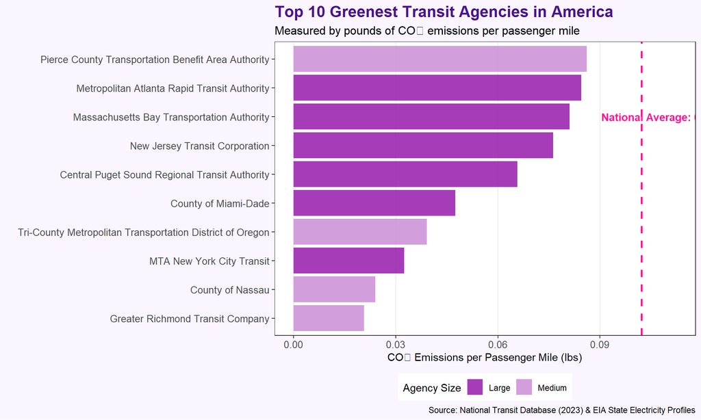

```r
library(scales)


top_agencies <- agency_emissions %>%
  filter(total_miles > 50000000) %>%
  arrange(co2_per_mile) %>%
  head(10)


ggplot(top_agencies, aes(x = reorder(`Agency Name`, co2_per_mile), y = co2_per_mile, fill = size_category)) +
  geom_bar(stat = "identity", alpha = 0.9) +
  geom_hline(yintercept = national_avg, linetype = "dashed", color = "#FF1493", size = 1) +
  annotate("text", x = 8, y = national_avg * 1.1,
           label = paste("National Average:", round(national_avg, 2), "lbs/mile"),
           color = "#FF1493", fontface = "bold") +
  coord_flip() +
  labs(
    title = "Top 10 Greenest Transit Agencies in America",
    subtitle = "Measured by pounds of CO₂ emissions per passenger mile",
    x = "",
    y = "CO₂ Emissions per Passenger Mile (lbs)",
    caption = "Source: National Transit Database (2023) & EIA State Electricity Profiles"
  ) +
  scale_fill_manual(values = c("Large" = "#9C27B0", "Medium" = "#CE93D8", "Small" = "#E1BEE7"),
                    name = "Agency Size") +
  scale_y_continuous(labels = label_number(accuracy = 0.01)) +
  theme_bw() +
  theme(
    plot.title = element_text(face = "bold", size = 16, color = "#4a148c"),
    plot.subtitle = element_text(size = 12),
    axis.text = element_text(size = 10),
    panel.grid.major.y = element_blank(),
    panel.grid.minor = element_blank(),
    legend.position = "bottom",
    plot.background = element_rect(fill = "#faf5ff", color = NA)
  )
```

### Visualization 2: Most Emissions Avoided Award - Using Professor’s Style

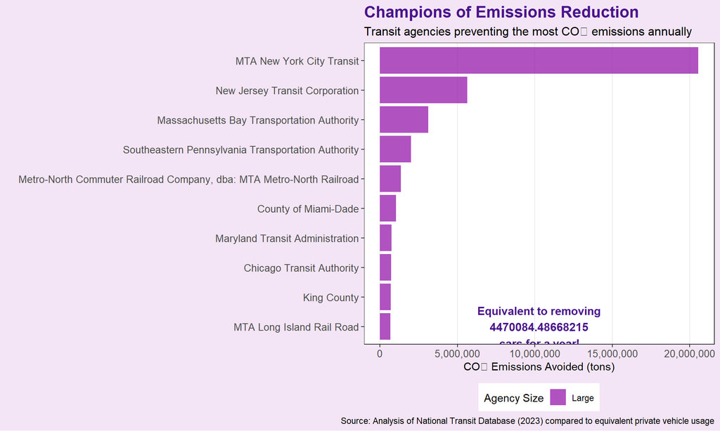

```r
top_emissions_avoided <- emissions_avoided %>%
  top_n(10, emissions_avoided_tons) %>%
  arrange(desc(emissions_avoided_tons))


top_emissions_avoided <- top_emissions_avoided %>%
  mutate(
    emissions_tons_numeric = as.numeric(gsub(",", "", emissions_avoided_tons)),
    cars_numeric = as.numeric(gsub(",", "", cars_equivalent))
  )


ggplot(top_emissions_avoided,
       aes(x = reorder(`Agency Name`, emissions_tons_numeric),
           y = emissions_tons_numeric,
           fill = size_category)) +
  geom_bar(stat = "identity", alpha = 0.8) +
  coord_flip() +
  scale_y_continuous(labels = label_comma()) +
  scale_fill_manual(values = c("Large" = "#9C27B0", "Medium" = "#CE93D8", "Small" = "#E1BEE7"),
                    name = "Agency Size") +
  labs(
    title = "Champions of Emissions Reduction",
    subtitle = "Transit agencies preventing the most CO₂ emissions annually",
    x = "",
    y = "CO₂ Emissions Avoided (tons)",
    caption = "Source: Analysis of National Transit Database (2023) compared to equivalent private vehicle usage"
  ) +
  theme_bw() +
  theme(
    plot.title = element_text(face = "bold", size = 16, color = "#4a148c"),
    plot.subtitle = element_text(size = 12),
    axis.text = element_text(size = 10),
    panel.grid.major.y = element_blank(),
    panel.grid.minor = element_blank(),
    legend.position = "bottom",
    plot.background = element_rect(fill = "#f3e5f5", color = NA)
  ) +

  annotate("text", x = 1, y = top_emissions_avoided$emissions_tons_numeric[1] * 0.5,
           label = paste("Equivalent to removing\n",
                        top_emissions_avoided$cars_equivalent[1],
                        "\ncars for a year!"),
           color = "#4a148c", fontface = "bold", hjust = 0.5, size = 4)
```

### Visualization 3: Electric vs Emissions Scatterplot - Professor-Style Analysis

```r
if (!requireNamespace("gganimate", quietly = TRUE)) {
  install.packages("gganimate")
}


library(gganimate)
packageVersion("gganimate")
```

```
[1] '1.0.9'
```

```r
if (!requireNamespace("gifski", quietly = TRUE)) {
  install.packages("gifski")
}
if (!requireNamespace("transformr", quietly = TRUE)) {
  install.packages("transformr")
}
library(gifski)
library(transformr)
```

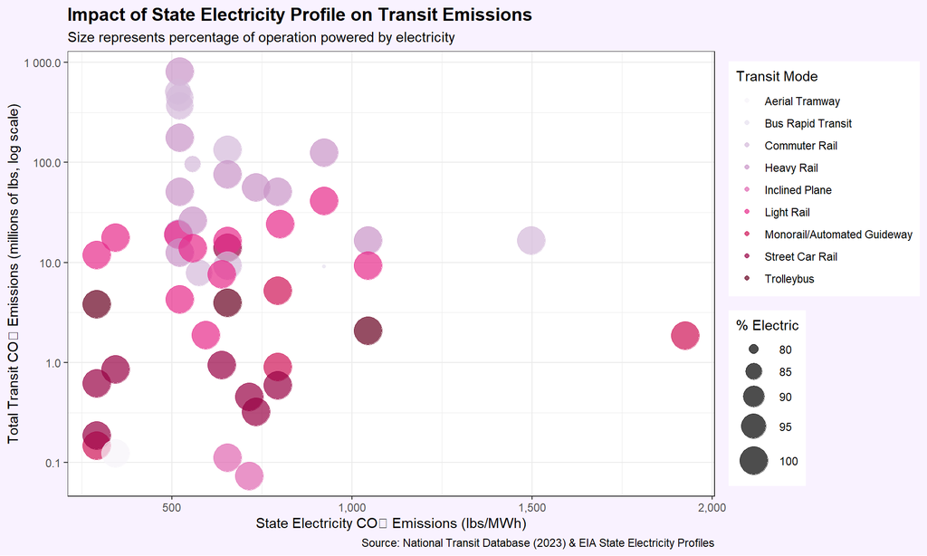

```r
scatter_data <- emissions_data %>%
  filter(!is.na(CO2_MWh), `Electric Propulsion` > 0) %>%

  mutate(
    total_energy = `Bio-Diesel` + `Bunker Fuel` + `C Natural Gas` +
                 `Diesel Fuel` + `Electric Battery` + `Electric Propulsion` +
                 Ethanol + Methonal + Gasoline + Hydrogen + Kerosene +
                 `Liquified Nat Gas` + `Liquified Petroleum Gas`,
    pct_electric = (`Electric Battery` + `Electric Propulsion`) / total_energy * 100,

    energy_scale = log10(total_energy)
  ) %>%

  filter(total_energy > 100000)


ggplot(scatter_data,
       aes(x = CO2_MWh,
           y = total_co2_emissions / 1000000,
           color = Mode,
           size = pct_electric)) +
  geom_point(alpha = 0.7) +
  scale_y_log10(labels = label_number()) +
  scale_x_continuous(labels = label_comma()) +
  scale_size_continuous(name = "% Electric", range = c(1, 10)) +
  scale_color_brewer(palette = "PuRd", name = "Transit Mode") +
  labs(
    title = "Impact of State Electricity Profile on Transit Emissions",
    subtitle = "Size represents percentage of operation powered by electricity",
    x = "State Electricity CO₂ Emissions (lbs/MWh)",
    y = "Total Transit CO₂ Emissions (millions of lbs, log scale)",
    caption = "Source: National Transit Database (2023) & EIA State Electricity Profiles"
  ) +
  theme_bw() +
  theme(
    plot.title = element_text(face = "bold", size = 14),
    legend.position = "right",
    plot.background = element_rect(fill = "#f9f2ff", color = NA)
  )
```

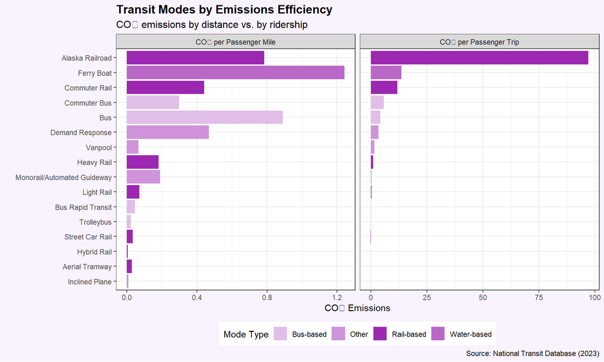

```r
transit_modes_data <- normalized_emissions %>%
  filter(!is.na(Mode), !is.na(co2_per_mile), !is.na(co2_per_upt)) %>%
  group_by(Mode) %>%
  summarize(
    total_co2 = sum(total_co2_emissions, na.rm = TRUE),
    total_miles = sum(MILES, na.rm = TRUE),
    total_trips = sum(UPT, na.rm = TRUE),
    co2_per_mile = mean(co2_per_mile, na.rm = TRUE),
    co2_per_trip = mean(co2_per_upt, na.rm = TRUE),
    .groups = "drop"
  ) %>%

  filter(total_co2 > 0, total_miles > 1000000, !is.na(Mode)) %>%

  mutate(mode_type = case_when(
    grepl("Rail|Tramway|Car", Mode) ~ "Rail-based",
    grepl("Bus|Trolleybus", Mode) ~ "Bus-based",
    grepl("Ferry|Boat", Mode) ~ "Water-based",
    TRUE ~ "Other"
  ))


transit_modes_long <- pivot_longer(
  transit_modes_data,
  cols = c(co2_per_mile, co2_per_trip),
  names_to = "metric",
  values_to = "value"
) %>%
mutate(
  metric_label = case_when(
    metric == "co2_per_mile" ~ "CO₂ per Passenger Mile",
    metric == "co2_per_trip" ~ "CO₂ per Passenger Trip",
    TRUE ~ metric
  )
)


ggplot(transit_modes_long,
       aes(x = reorder(Mode, value),
           y = value,
           fill = mode_type)) +
  geom_col() +
  coord_flip() +
  facet_wrap(~metric_label, scales = "free_x") +
  scale_fill_manual(values = c(
    "Rail-based" = "#9C27B0",
    "Bus-based" = "#E1BEE7",
    "Water-based" = "#BA68C8",
    "Other" = "#CE93D8"
  )) +
  labs(
    title = "Transit Modes by Emissions Efficiency",
    subtitle = "CO₂ emissions by distance vs. by ridership",
    x = "",
    y = "CO₂ Emissions",
    fill = "Mode Type",
    caption = "Source: National Transit Database (2023)"
  ) +
  theme_bw() +
  theme(
    plot.title = element_text(face = "bold", size = 14),
    plot.subtitle = element_text(size = 12),
    legend.position = "bottom",
    plot.background = element_rect(fill = "#f9f2ff", color = NA)
  )
```

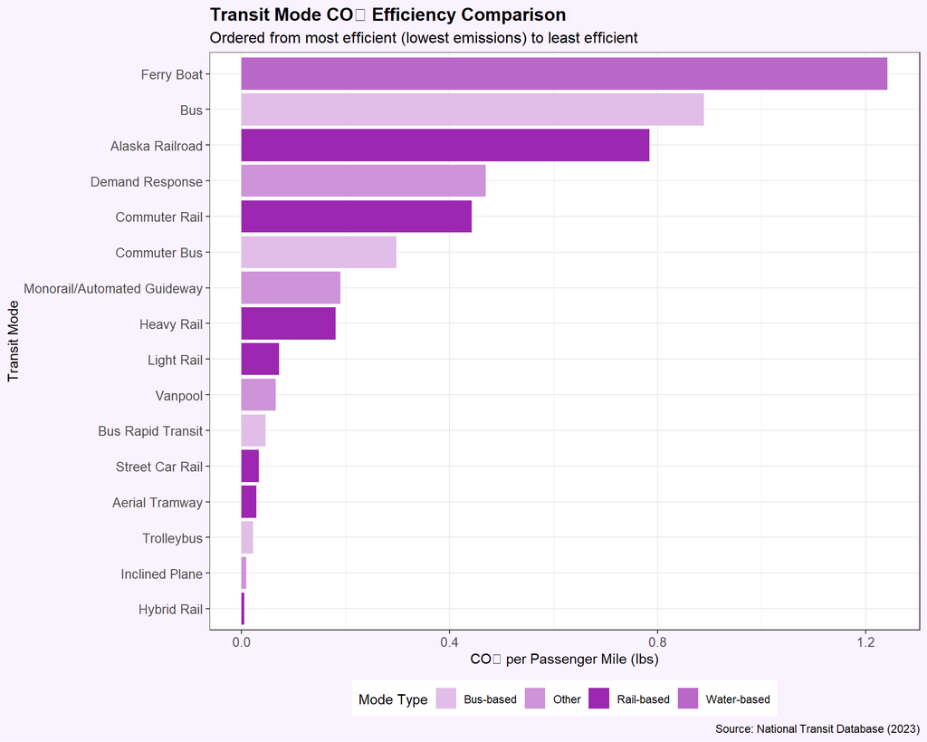

```r
mode_efficiency_static <- normalized_emissions %>%
  filter(!is.na(Mode), !is.na(co2_per_mile)) %>%
  group_by(Mode) %>%
  summarize(
    avg_co2_per_mile = mean(co2_per_mile, na.rm = TRUE),
    total_miles = sum(MILES, na.rm = TRUE),
    mode_type = first(case_when(
      grepl("Rail|Tramway|Car", Mode) ~ "Rail-based",
      grepl("Bus|Trolleybus", Mode) ~ "Bus-based",
      grepl("Ferry|Boat", Mode) ~ "Water-based",
      TRUE ~ "Other"
    )),
    .groups = "drop"
  ) %>%

  filter(total_miles > 1000000) %>%

  arrange(avg_co2_per_mile)


ggplot(mode_efficiency_static,
       aes(x = reorder(Mode, avg_co2_per_mile),
           y = avg_co2_per_mile,
           fill = mode_type)) +
  geom_col() +
  coord_flip() +
  scale_fill_manual(values = c(
    "Rail-based" = "#9C27B0",
    "Bus-based" = "#E1BEE7",
    "Water-based" = "#BA68C8",
    "Other" = "#CE93D8"
  )) +
  labs(
    title = "Transit Mode CO₂ Efficiency Comparison",
    subtitle = "Ordered from most efficient (lowest emissions) to least efficient",
    x = "Transit Mode",
    y = "CO₂ per Passenger Mile (lbs)",
    fill = "Mode Type",
    caption = "Source: National Transit Database (2023)"
  ) +
  theme_bw() +
  theme(
    plot.title = element_text(face = "bold", size = 14),
    plot.subtitle = element_text(size = 12),
    axis.text = element_text(size = 10),
    legend.position = "bottom",
    plot.background = element_rect(fill = "#f9f2ff", color = NA)
  )
```

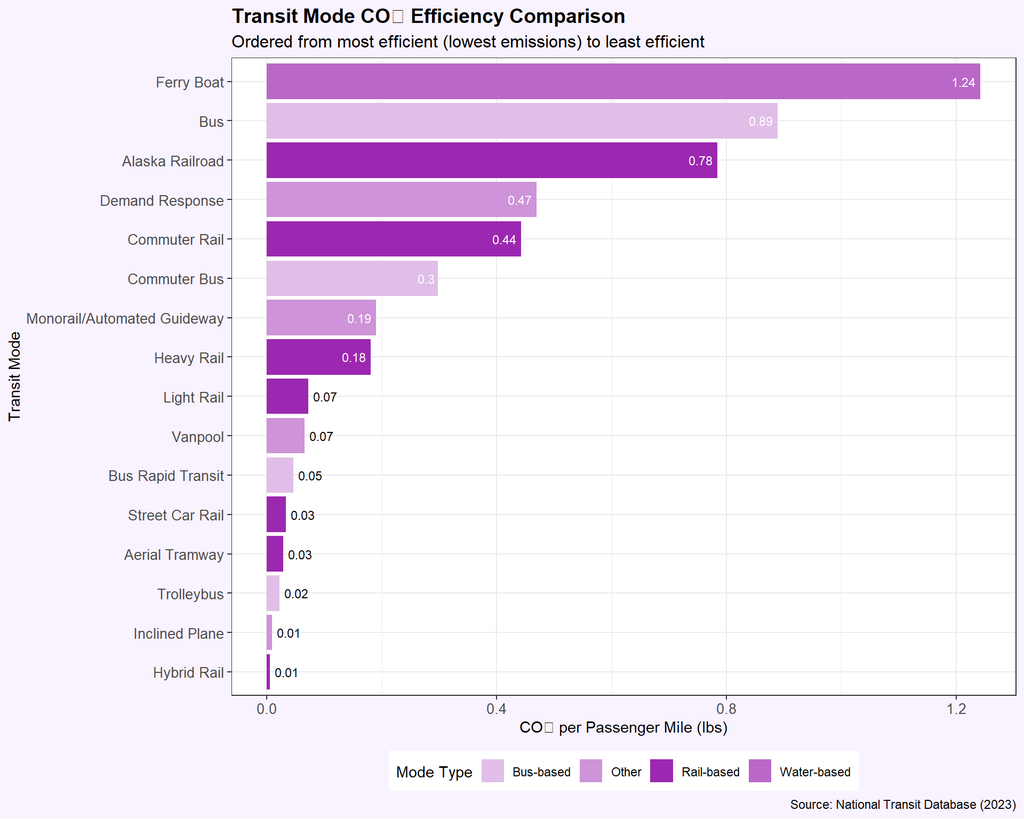

```r
most_efficient <- mode_efficiency_static %>% slice(1)
least_efficient <- mode_efficiency_static %>% slice(n())


ggplot(mode_efficiency_static,
       aes(x = reorder(Mode, avg_co2_per_mile),
           y = avg_co2_per_mile,
           fill = mode_type)) +
  geom_col() +
  coord_flip() +
  geom_text(
    data = filter(mode_efficiency_static, avg_co2_per_mile < median(avg_co2_per_mile)),
    aes(label = round(avg_co2_per_mile, 2)),
    hjust = -0.2,
    size = 3
  ) +
  geom_text(
    data = filter(mode_efficiency_static, avg_co2_per_mile >= median(avg_co2_per_mile)),
    aes(label = round(avg_co2_per_mile, 2)),
    hjust = 1.2,
    color = "white",
    size = 3
  ) +
  scale_fill_manual(values = c(
    "Rail-based" = "#9C27B0",
    "Bus-based" = "#E1BEE7",
    "Water-based" = "#BA68C8",
    "Other" = "#CE93D8"
  )) +
  labs(
    title = "Transit Mode CO₂ Efficiency Comparison",
    subtitle = "Ordered from most efficient (lowest emissions) to least efficient",
    x = "Transit Mode",
    y = "CO₂ per Passenger Mile (lbs)",
    fill = "Mode Type",
    caption = "Source: National Transit Database (2023)"
  ) +
  theme_bw() +
  theme(
    plot.title = element_text(face = "bold", size = 14),
    plot.subtitle = element_text(size = 12),
    axis.text = element_text(size = 10),
    legend.position = "bottom",
    plot.background = element_rect(fill = "#f9f2ff", color = NA)
  )
```

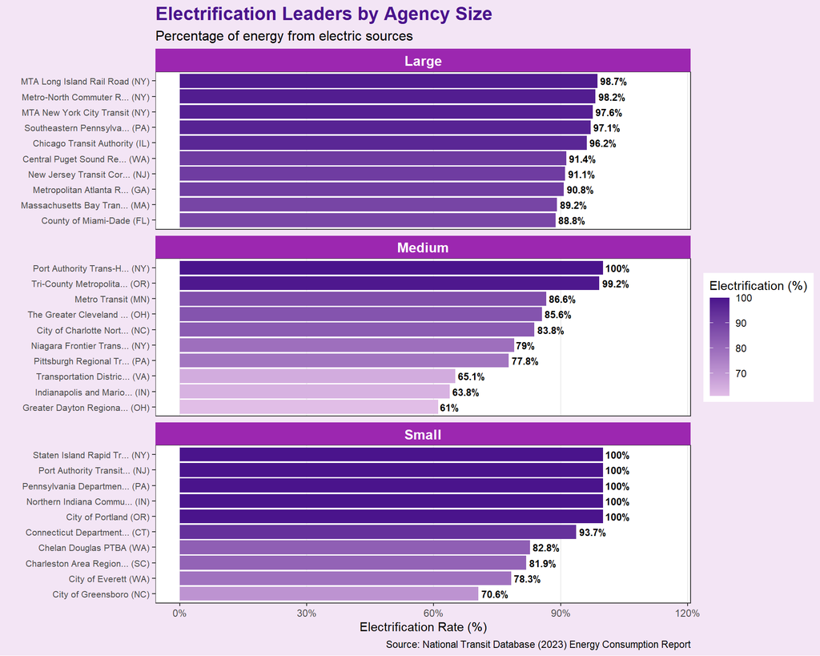

```r
electrification_by_size <- electrification %>%
  left_join(agency_emissions %>% select(`Agency Name`, State, size_category),
            by = c("Agency Name", "State")) %>%
  filter(!is.na(size_category)) %>%
  filter(total_energy > 1000000) %>%

  group_by(size_category) %>%
  mutate(rank_in_group = min_rank(desc(electrification_rate))) %>%
  filter(rank_in_group <= 10) %>%
  mutate(
    display_name = ifelse(
      nchar(`Agency Name`) > 25,
      paste0(substr(`Agency Name`, 1, 22), "..."),
      `Agency Name`
    ),

    agency_label = paste0(display_name, " (", State, ")")
  )


ggplot(electrification_by_size,
       aes(x = reorder(agency_label, electrification_rate),
           y = electrification_rate)) +
  geom_bar(stat = "identity", aes(fill = electrification_rate)) +

  geom_text(
    aes(label = paste0(round(electrification_rate, 1), "%")),
    hjust = -0.1,
    size = 3,
    fontface = "bold"
  ) +
  facet_wrap(~ size_category, scales = "free_y", ncol = 1) +
  coord_flip() +
  scale_fill_gradient(low = "#E1BEE7", high = "#4A148C", name = "Electrification (%)") +
  scale_y_continuous(
    labels = function(x) paste0(x, "%"),
    limits = function(x) c(0, max(x) * 1.15) # Add space for labels
  ) +
  labs(
    title = "Electrification Leaders by Agency Size",
    subtitle = "Percentage of energy from electric sources",
    x = "",
    y = "Electrification Rate (%)",
    caption = "Source: National Transit Database (2023) Energy Consumption Report"
  ) +
  theme_bw() +
  theme(
    plot.title = element_text(face = "bold", size = 16, color = "#4A148C"),
    plot.subtitle = element_text(size = 12),
    strip.background = element_rect(fill = "#9C27B0", color = NA),
    strip.text = element_text(color = "white", face = "bold", size = 12),
    axis.text.y = element_text(size = 8),
    legend.position = "right",
    plot.background = element_rect(fill = "#f3e5f5", color = NA),
    panel.grid.major.y = element_blank(),
    panel.grid.minor = element_blank()
  )
```

## Conclusion

This analysis has identified the most environmentally responsible transit agencies in the United States based on several key metrics. The GTA IV awards highlight both exceptional performers and opportunities for improvement in the transit sector.

Transit agencies looking to improve their environmental performance should focus on:

1. Increasing electrification, particularly in states with clean electricity
2. Boosting ridership to improve per-passenger efficiency
3. Optimizing routes to maximize passenger miles while minimizing fuel consumption

Future research could explore how agencies might adapt to changing electricity profiles as states transition to cleaner energy sources, and the potential impacts of federal infrastructure funding on transit emissions.

## References

1. Energy Information Administration. (2023). State Electricity Profiles. https://www.eia.gov/electricity/state/
2. Federal Transit Administration. (2023). National Transit Database Energy Consumption Report. https://www.transit.dot.gov/
3. Federal Transit Administration. (2023). National Transit Database Service by Agency Report. https://data.transportation.gov/
4. Environmental Protection Agency. (2023). Emission Factors for Greenhouse Gas Inventories. https://www.epa.gov/sites/default/files/2021-04/documents/emission-factors_apr2021.pdf